# Movement Analysis

Kaytlin Edwards

2026-11-20

This analysis examines potential variation in observation intervals, movement distances and estimated speeds for each of the tracked flatback turtles in this study.

### Load Required Packages

```r
library(tidyverse)
library(here)
library(geosphere)
```

## Import Cleaned Tracking Data

The cleaned tracking dataset was imported from the previous data preparation stage.

```r
turtle_clean <- read_csv(
  here("outputs", "Peak_TurtleTracking_Cleaned.csv"),
  show_col_types = FALSE
)

# Ensure timestamps are recognised as dates and times
turtle_clean <- turtle_clean %>%
  mutate(datetime = as.POSIXct(datetime, tz = "UTC")) %>%
  arrange(Turtleid, datetime)

glimpse(turtle_clean)
```

```
## Rows: 2,381
## Columns: 12
## $ Turtleid                   <dbl> 267827, 267827, 267827, 267827, 267827, 267…
## $ Date                       <chr> "27/10/2024", "27/10/2024", "27/10/2024", "…
## $ Time                       <time> 17:36:00, 18:22:00, 18:52:00, 19:22:00, 19…
## $ lat                        <dbl> -23.34308, -23.34312, -23.34288, -23.34281,…
## $ lon                        <dbl> 150.9343, 150.9333, 150.9333, 150.9334, 150…
## $ ClutchInterval             <dbl> 2, 2, 2, 2, 2, 2, 2, 2, 2, 2, 2, 2, 2, 2, 2…
## $ id_clutchinterval          <chr> NA, NA, NA, NA, NA, NA, NA, NA, NA, NA, NA,…
## $ datetime                   <dttm> 2024-10-27 17:36:00, 2024-10-27 18:22:00, …
## $ time_since_previous_min    <dbl> NA, 46, 30, 30, 30, 30, 30, 30, 30, 30, 30,…
## $ distance_since_previous_m  <dbl> NA, 107.41056, 26.71668, 13.67930, 18.83728…
## $ distance_since_previous_km <dbl> NA, 0.10741056, 0.02671668, 0.01367930, 0.0…
## $ speed_kmh                  <dbl> NA, 0.14010073, 0.05343336, 0.02735861, 0.0…
```

# Movement Calculations

## Calculating Time Between Observations

The time between consecutive satellite-tracking observations was calculated for each independent turtle using `group_by()`, `lag()` and `difftime()`. These time Intervals are expressed in minutes.

```r
turtle_clean <- turtle_clean %>%
  group_by(Turtleid) %>%
  mutate(
    time_since_previous_min = as.numeric(
      difftime(datetime, lag(datetime), units = "mins")
    )
  ) %>%
  ungroup()

# Inspect calculated observation intervals
turtle_clean %>%
  select(Turtleid, datetime, time_since_previous_min) %>%
  print(n = 15)
```

```
## # A tibble: 2,381 × 3
##    Turtleid datetime            time_since_previous_min
##       <dbl> <dttm>                                <dbl>
##  1   267827 2024-10-27 17:36:00                      NA
##  2   267827 2024-10-27 18:22:00                      46
##  3   267827 2024-10-27 18:52:00                      30
##  4   267827 2024-10-27 19:22:00                      30
##  5   267827 2024-10-27 19:52:00                      30
##  6   267827 2024-10-27 20:22:00                      30
##  7   267827 2024-10-27 20:52:00                      30
##  8   267827 2024-10-27 21:22:00                      30
##  9   267827 2024-10-27 21:52:00                      30
## 10   267827 2024-10-27 22:22:00                      30
## 11   267827 2024-10-27 22:52:00                      30
## 12   267827 2024-10-27 22:53:00                       1
## 13   267827 2024-10-27 23:47:00                      54
## 14   267827 2024-10-28 00:22:00                      35
## 15   267827 2024-10-28 00:28:00                       6
## # ℹ 2,366 more rows
```

## Calculating Distance Between Observations

The geographical distance between consecutive observation locations was calculated using the Haversine formula through `geosphere::distHaversine()`. Distances were calculated in metres and converted to kilometres for personal preference.

```r
turtle_clean <- turtle_clean %>%
  group_by(Turtleid) %>%
  mutate(
    distance_since_previous_m = geosphere::distHaversine(
      cbind(lag(lon), lag(lat)),
      cbind(lon, lat)
    )
  ) %>%
  ungroup()

# Inspect calculated distances
turtle_clean %>%
  select(Turtleid, datetime,
         time_since_previous_min,
         distance_since_previous_m) %>%
  print(n = 15)
```

```
## # A tibble: 2,381 × 4
##    Turtleid datetime            time_since_previous_min distance_since_previou…¹
##       <dbl> <dttm>                                <dbl>                    <dbl>
##  1   267827 2024-10-27 17:36:00                      NA                     NA
##  2   267827 2024-10-27 18:22:00                      46                    107.
##  3   267827 2024-10-27 18:52:00                      30                     26.7
##  4   267827 2024-10-27 19:22:00                      30                     13.7
##  5   267827 2024-10-27 19:52:00                      30                     18.8
##  6   267827 2024-10-27 20:22:00                      30                     32.6
##  7   267827 2024-10-27 20:52:00                      30                    264.
##  8   267827 2024-10-27 21:22:00                      30                    208.
##  9   267827 2024-10-27 21:52:00                      30                     45.7
## 10   267827 2024-10-27 22:22:00                      30                     48.7
## 11   267827 2024-10-27 22:52:00                      30                    114.
## 12   267827 2024-10-27 22:53:00                       1                     48.9
## 13   267827 2024-10-27 23:47:00                      54                   1369.
## 14   267827 2024-10-28 00:22:00                      35                    431.
## 15   267827 2024-10-28 00:28:00                       6                    107.
## # ℹ 2,366 more rows
## # ℹ abbreviated name: ¹distance_since_previous_m
```

```r
# Convert metres to kilometres (personal preference)
turtle_clean <- turtle_clean %>%
  mutate(
    distance_since_previous_km =
      distance_since_previous_m / 1000
  )

# Inspect calculated movement distances
turtle_clean %>%
  select(
    Turtleid,
    datetime,
    distance_since_previous_m,
    distance_since_previous_km
  ) %>%
  print(n = 15)
```

```
## # A tibble: 2,381 × 4
##    Turtleid datetime            distance_since_previous_m distance_since_previ…¹
##       <dbl> <dttm>                                  <dbl>                  <dbl>
##  1   267827 2024-10-27 17:36:00                      NA                  NA
##  2   267827 2024-10-27 18:22:00                     107.                  0.107
##  3   267827 2024-10-27 18:52:00                      26.7                 0.0267
##  4   267827 2024-10-27 19:22:00                      13.7                 0.0137
##  5   267827 2024-10-27 19:52:00                      18.8                 0.0188
##  6   267827 2024-10-27 20:22:00                      32.6                 0.0326
##  7   267827 2024-10-27 20:52:00                     264.                  0.264
##  8   267827 2024-10-27 21:22:00                     208.                  0.208
##  9   267827 2024-10-27 21:52:00                      45.7                 0.0457
## 10   267827 2024-10-27 22:22:00                      48.7                 0.0487
## 11   267827 2024-10-27 22:52:00                     114.                  0.114
## 12   267827 2024-10-27 22:53:00                      48.9                 0.0489
## 13   267827 2024-10-27 23:47:00                    1369.                  1.37
## 14   267827 2024-10-28 00:22:00                     431.                  0.431
## 15   267827 2024-10-28 00:28:00                     107.                  0.107
## # ℹ 2,366 more rows
## # ℹ abbreviated name: ¹distance_since_previous_km
```

## Calculating Estimated Speed

Estimated movement speed was calculated by dividing the straight-line distance between consecutive satellite locations by the elapsed time in hours. Speeds are expressed in kilometres per hour (km/h). Observations with zero or missing time intervals were assigned to ‘NA’.

```r
turtle_clean <- turtle_clean %>%
  mutate(
    speed_kmh = if_else(
      time_since_previous_min > 0,
      distance_since_previous_km /
        (time_since_previous_min / 60),
      NA_real_
    )
  )
# Inspect calculated movement speeds
turtle_clean %>%
  select(
    Turtleid,
    datetime,
    time_since_previous_min,
    distance_since_previous_km,
    speed_kmh
  ) %>%
  print(n = 15)
```

```
## # A tibble: 2,381 × 5
##    Turtleid datetime            time_since_previous_min distance_since_previou…¹
##       <dbl> <dttm>                                <dbl>                    <dbl>
##  1   267827 2024-10-27 17:36:00                      NA                  NA
##  2   267827 2024-10-27 18:22:00                      46                   0.107
##  3   267827 2024-10-27 18:52:00                      30                   0.0267
##  4   267827 2024-10-27 19:22:00                      30                   0.0137
##  5   267827 2024-10-27 19:52:00                      30                   0.0188
##  6   267827 2024-10-27 20:22:00                      30                   0.0326
##  7   267827 2024-10-27 20:52:00                      30                   0.264
##  8   267827 2024-10-27 21:22:00                      30                   0.208
##  9   267827 2024-10-27 21:52:00                      30                   0.0457
## 10   267827 2024-10-27 22:22:00                      30                   0.0487
## 11   267827 2024-10-27 22:52:00                      30                   0.114
## 12   267827 2024-10-27 22:53:00                       1                   0.0489
## 13   267827 2024-10-27 23:47:00                      54                   1.37
## 14   267827 2024-10-28 00:22:00                      35                   0.431
## 15   267827 2024-10-28 00:28:00                       6                   0.107
## # ℹ 2,366 more rows
## # ℹ abbreviated name: ¹distance_since_previous_km
## # ℹ 1 more variable: speed_kmh <dbl>
```

```r
# Inspect estimated movement speeds
summary(turtle_clean$speed_kmh)
```

```
##      Min.   1st Qu.    Median      Mean   3rd Qu.      Max.      NA's
##  0.003246  0.113819  0.299963  0.577660  0.742225 17.404956         7
```

### Examine Unusually High Movement Speeds

Abnormally high estimated speeds may result from short intervals between satellite observations. The ten highest estimates were examined with their associated distances and observation intervals, and sum(is.na()) was used to count observations with missing values

```r
turtle_clean %>%
  arrange(desc(speed_kmh)) %>%
  select(
    Turtleid,
    datetime,
    time_since_previous_min,
    distance_since_previous_km,
    speed_kmh
  ) %>%
  head(10) %>%
  print(width = Inf)
```

```
## # A tibble: 10 × 5
##    Turtleid datetime            time_since_previous_min
##       <dbl> <dttm>                                <dbl>
##  1   267829 2024-11-06 08:43:00                       1
##  2   267832 2024-10-30 20:39:00                       1
##  3   267829 2024-11-27 21:49:00                       1
##  4   267827 2024-11-12 19:18:00                       4
##  5   267838 2024-11-10 08:20:00                       1
##  6   267832 2024-10-29 06:11:00                       1
##  7   267827 2024-11-01 20:25:00                       1
##  8   267832 2024-10-28 10:56:00                       1
##  9   267829 2024-10-27 06:48:00                       1
## 10   267834 2024-11-08 12:19:00                       1
##    distance_since_previous_km speed_kmh
##                         <dbl>     <dbl>
##  1                     0.290      17.4
##  2                     0.202      12.1
##  3                     0.186      11.2
##  4                     0.713      10.7
##  5                     0.169      10.2
##  6                     0.136       8.18
##  7                     0.114       6.83
##  8                     0.0862      5.17
##  9                     0.0859      5.15
## 10                     0.0858      5.15
```

```r
# Count observations with missing speed values
sum(is.na(turtle_clean$speed_kmh))
```

```
## [1] 7
```

## Examine Observation Interval Distribution

The satellite transmitters were programmed to record locations at 30-minute intervals; however, successful transmissions depended on turtles surfacing and exposing the transmitter above water. Environmental conditions - strong winds, rough seas and wave activity - may have influenced time interval variation by limiting transmitter exposure. As such, recorded observations occurred at irregular intervals which often exceeded 30 minutes. The distribution of elapsed times was examined to assess how variation in sampling frequency could influence estimated movement speeds.

```r
summary(turtle_clean$time_since_previous_min)
```

```
##    Min. 1st Qu.  Median    Mean 3rd Qu.    Max.    NA's
##     1.0    39.0    82.0   148.2   186.0  1616.0       7
```

```r
turtle_clean %>%
  count(time_since_previous_min, sort = TRUE) %>%
  print(n = 30)
```

```
## # A tibble: 518 × 2
##    time_since_previous_min     n
##                      <dbl> <int>
##  1                      30   131
##  2                       1    92
##  3                      31    48
##  4                      35    36
##  5                      33    32
##  6                       2    28
##  7                      34    27
##  8                      39    26
##  9                      32    25
## 10                      37    23
## 11                      38    22
## 12                      42    21
```

[output cut: 19 more lines]

## Flag Short Observation Intervals

Observation intervals shorter than five minutes were provisionally flagged for quality-control purposes, but retained in the original dataset.

```r
turtle_clean <- turtle_clean %>%
  mutate(
    short_interval_flag =
      !is.na(time_since_previous_min) &
      time_since_previous_min < 5
  )

# Count flagged and unflagged observations
turtle_clean %>%
  count(short_interval_flag)
```

```
## # A tibble: 2 × 2
##   short_interval_flag     n
##   <lgl>               <int>
## 1 FALSE                2244
## 2 TRUE                  137
```

# Individual Turtle Movement Summaries

Movement characteristics for each of the seven flatback turtles was summarised to compare tracking duration, observation frequency, cumulative movement distance and median estimated speed.

## Calculate Individual Turtle Summaries

```r
turtle_summary <- turtle_clean %>%
  group_by(Turtleid) %>%
  summarise(
    observations = n(),

    tracking_days = as.numeric(
      difftime(max(datetime), min(datetime), units = "days")
    ),

    median_interval_min = median(
      time_since_previous_min, na.rm = TRUE
    ),

    cumulative_distance_km = sum(
      distance_since_previous_km, na.rm = TRUE
    ),

    median_speed_kmh = median(
      speed_kmh, na.rm = TRUE
    ),

    .groups = "drop"
  )

# View summary table
print(turtle_summary, width = Inf)
```

```
## # A tibble: 7 × 6
##   Turtleid observations tracking_days median_interval_min cumulative_distance_km
##      <dbl>        <int>         <dbl>               <dbl>                  <dbl>
## 1   267827          272          29.2                  86                   277.
## 2   267829          546          32.3                  58                   214.
## 3   267830          445          54.0                 110                   342.
## 4   267832          315          31.7                  71                   314.
## 5   267834          194          32.2                 131                   294.
## 6   267837          325          32.8                  86                   322.
## 7   267838          284          32.2                 102                   303.
##   median_speed_kmh
##              <dbl>
## 1            0.324
## 2            0.268
## 3            0.208
## 4            0.403
## 5            0.317
## 6            0.322
## 7            0.365
```

## Median Observation Intervals by Turtle

Median observation intervals were compared among the seven turtles to examine differences in the frequency of successful satellite-tracking observations.

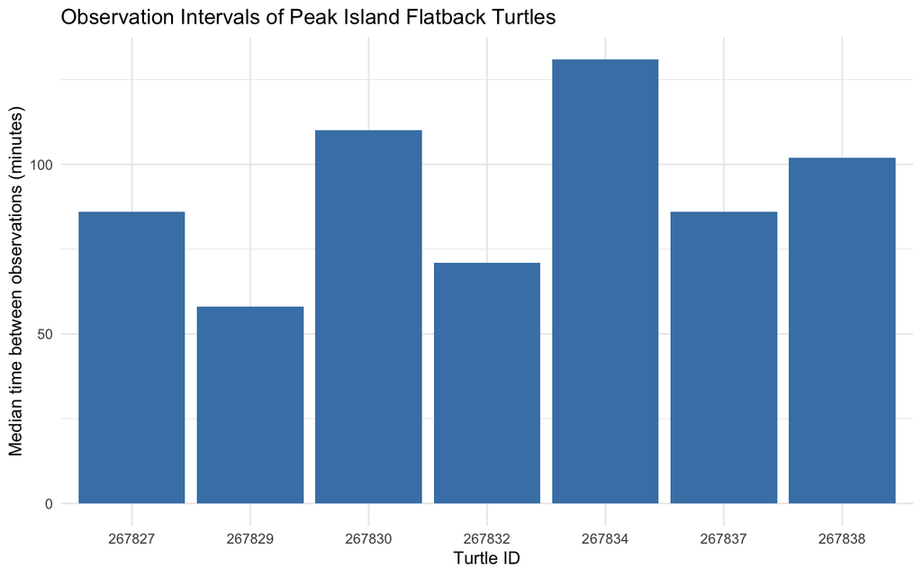

```r
ggplot(turtle_summary,
       aes(x = factor(Turtleid),
           y = median_interval_min)) +
  geom_col(fill = "steelblue") +
  labs(
    title = "Observation Intervals of Peak Island Flatback Turtles",
    x = "Turtle ID",
    y = "Median time between observations (minutes)"
  ) +
  theme_minimal()
```

## Median Estimated Movement Speed by Turtle

Median estimated movement speeds compared among individual turtles to explore differences in movement speed and energy exertion during successive inter-nesting periods for each turtle.

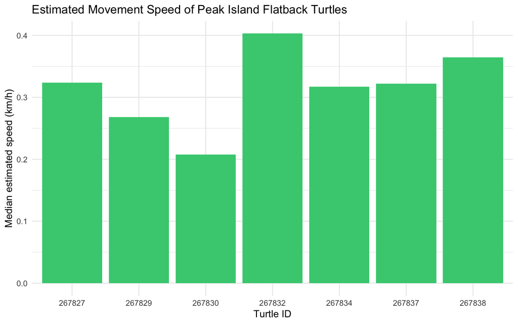

```r
ggplot(turtle_summary,
       aes(x = factor(Turtleid),
           y = median_speed_kmh)) +
  geom_col(fill = "seagreen3") +
  labs(
    title = "Estimated Movement Speed of Peak Island Flatback Turtles",
    x = "Turtle ID",
    y = "Median estimated speed (km/h)"
  ) +
  theme_minimal()
```

# Movement Patterns Across Clutch Intervals

Summarize movement patterns for each turtle and clutch interval to analyse variation in observation frequency, movement distances and estimated speeds throughout the inter-nesting periods.

## Calculate Clutch Interval Summaries

```r
clutch_summary <- turtle_clean %>%
  group_by(Turtleid, ClutchInterval) %>%
  summarise(
    observations = n(),

    mean_interval_min = mean(
      time_since_previous_min, na.rm = TRUE
    ),

    median_interval_min = median(
      time_since_previous_min, na.rm = TRUE
    ),

    mean_distance_km = mean(
      distance_since_previous_km, na.rm = TRUE
    ),

    median_distance_km = median(
      distance_since_previous_km, na.rm = TRUE
    ),

    mean_speed_kmh = mean(
      speed_kmh, na.rm = TRUE
    ),

    median_speed_kmh = median(
      speed_kmh, na.rm = TRUE
    ),

    cumulative_distance_km = sum(
      distance_since_previous_km, na.rm = TRUE
    ),

    .groups = "drop"
  )

# View expanded summary
print(clutch_summary, n = Inf, width = Inf)
```

```
## # A tibble: 17 × 10
##    Turtleid ClutchInterval observations mean_interval_min median_interval_min
##       <dbl>          <dbl>        <int>             <dbl>               <dbl>
##  1   267827              2          174             127                  73
##  2   267827              3           98             205.                117
##  3   267829              2          290              74.5                50
##  4   267829              3          256              97.9                63.5
##  5   267830              2          145             139.                 81
##  6   267830              3          108             174.                110.
##  7   267830              4           99             171.                124
##  8   267830              5           93             236.                154
##  9   267832              2          129             156.                109
## 10   267832              3          186             138.                 44
## 11   267834              2          110             201.                125
## 12   267834              3           84             292.                161
```

[output cut: 43 more lines]

## Distribution of Observation Intervals

The distribution of time between observations was examined using boxplots. The y-axis was set to 0–400 minutes to make differences in the more frequently occurring observation intervals easier to visualise.

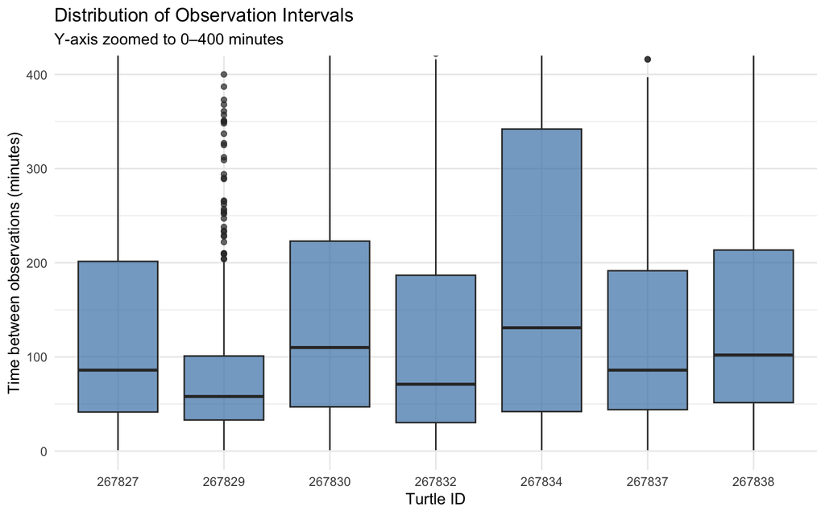

```r
ggplot(
  turtle_clean %>%
    filter(!is.na(time_since_previous_min)),
  aes(
    x = factor(Turtleid),
    y = time_since_previous_min
  )
) +
  geom_boxplot(fill = "steelblue", alpha = 0.7) +
  coord_cartesian(ylim = c(0, 400)) +
  labs(
    title = "Distribution of Observation Intervals",
    subtitle = "Y-axis zoomed to 0–400 minutes",
    x = "Turtle ID",
    y = "Time between observations (minutes)"
  ) +
  theme_minimal()
```

## Compare Mean and Median Observation Intervals Across Clutch Intervals

Mean and median observation intervals were compared across clutch intervals for each turtle. Comparing these measures helps identify differences in sampling frequency and the influence of unusually long gaps between successful satellite transmissions.

```r
# Compare mean and median intervals across clutch intervals
clutch_plot <- clutch_summary %>%
  select(
    Turtleid,
    ClutchInterval,
    mean_interval_min,
    median_interval_min
  ) %>%
  pivot_longer(
    cols = c(mean_interval_min, median_interval_min),
    names_to = "statistic",
    values_to = "interval_min"
  )
```

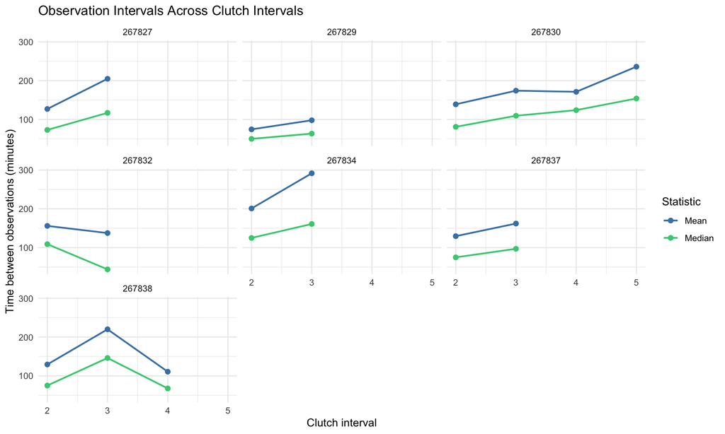

```r
# Plot mean and median observation intervals
ggplot(
  clutch_plot,
  aes(
    x = ClutchInterval,
    y = interval_min,
    colour = statistic,
    group = statistic
  )
) +
  geom_line(linewidth = 0.8) +
  geom_point(size = 2) +
  facet_wrap(~ Turtleid) +
  scale_x_continuous(breaks = 2:5) +
  scale_colour_manual(
    values = c(
      mean_interval_min = "steelblue",
      median_interval_min = "seagreen3"
    ),
    labels = c(
      mean_interval_min = "Mean",
      median_interval_min = "Median"
    )
  ) +
  labs(
    title = "Observation Intervals Across Clutch Intervals",
    x = "Clutch interval",
    y = "Time between observations (minutes)",
    colour = "Statistic"
  ) +
  theme_minimal()
```

## Mean and Median Estimated Movement Speeds Across Clutch Intervals

Mean and median estimated movement speeds were compared across clutch intervals for each turtle.

```r
# Compare mean and median movement speeds across clutch intervals
speed_plot <- clutch_summary %>%
  select(
    Turtleid,
    ClutchInterval,
    mean_speed_kmh,
    median_speed_kmh
  ) %>%
  pivot_longer(
    cols = c(mean_speed_kmh, median_speed_kmh),
    names_to = "statistic",
    values_to = "speed_kmh"
  )
```

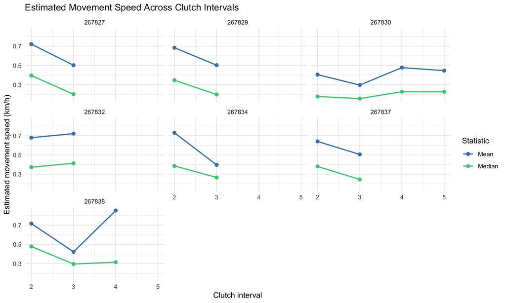

```r
# Visualise movement speeds across clutch intervals
ggplot(
  speed_plot,
  aes(
    x = ClutchInterval,
    y = speed_kmh,
    colour = statistic,
    group = statistic
  )
) +
  geom_line(linewidth = 0.8) +
  geom_point(size = 2) +
  facet_wrap(~ Turtleid) +
  scale_x_continuous(breaks = 2:5) +
  scale_colour_manual(
    values = c(
      mean_speed_kmh = "steelblue",
      median_speed_kmh = "seagreen3"
    ),
    labels = c(
      mean_speed_kmh = "Mean",
      median_speed_kmh = "Median"
    )
  ) +
  labs(
    title = "Estimated Movement Speed Across Clutch Intervals",
    x = "Clutch interval",
    y = "Estimated movement speed (km/h)",
    colour = "Statistic"
  ) +
  theme_minimal()
```

## Mean and Median Movement Distances Across Clutch Intervals

Mean and median straight-line distances between consecutive satellite-tracking locations were compared across clutch intervals for each turtle. These comparisons help examine variation in recorded movement distances while accounting for the influence of unusually large displacements.

```r
# Compare mean and median movement distances across clutch intervals
distance_plot <- clutch_summary %>%
  select(
    Turtleid,
    ClutchInterval,
    mean_distance_km,
    median_distance_km
  ) %>%
  pivot_longer(
    cols = c(mean_distance_km, median_distance_km),
    names_to = "statistic",
    values_to = "distance_km"
  )
```

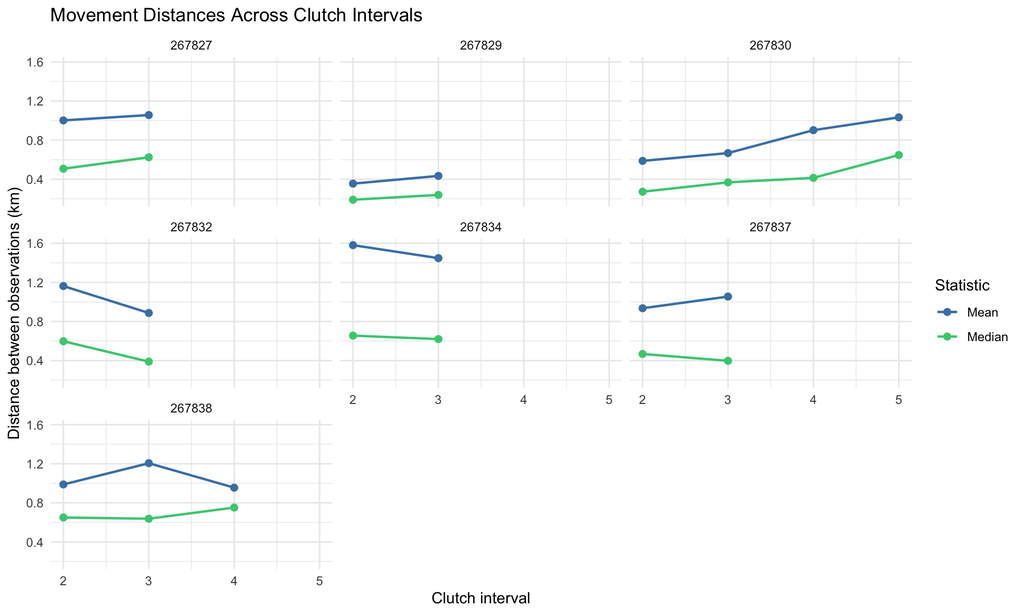

```r
# Visualise movement distances across clutch intervals
ggplot(
  distance_plot,
  aes(
    x = ClutchInterval,
    y = distance_km,
    colour = statistic,
    group = statistic
  )
) +
  geom_line(linewidth = 0.8) +
  geom_point(size = 2) +
  facet_wrap(~ Turtleid) +
  scale_x_continuous(breaks = 2:5) +
  scale_colour_manual(
    values = c(
      mean_distance_km = "steelblue",
      median_distance_km = "seagreen3"
    ),
    labels = c(
      mean_distance_km = "Mean",
      median_distance_km = "Median"
    )
  ) +
  labs(
    title = "Movement Distances Across Clutch Intervals",
    x = "Clutch interval",
    y = "Distance between observations (km)",
    colour = "Statistic"
  ) +
  theme_minimal()
```